# Evaluation of pupation time with *drug* and the *mut<sup>1</sup>* allele

## 1. Computing tools

### Libraries

```r
# data handling
library(readxl)
# stats
library(survival)
library(survminer)
# for plotting
library(ggthemes) # italics in the figures
library(ggtext) # italics in the figures
library(RColorBrewer)
```

### Custom function `analyse_spreadsheet`

```r
devtools::source_url('https://raw.githubusercontent.com/jdenavascues/Survival_functions/main/development.R')
#devtools::source_url('https://raw.githubusercontent.com/jdenavascues/Survival_functions/master/development.R')
```

## 2. Experiment parameters

- Start date: 21.11.2022
- Lab members: Keri-Ann
- Genotypes: *wild-type*, *mut<sup>1</sup>*
- Treatment: drug 0mM / 50mM
- Treatment method: mixed in melted food, with E133 dye.

## 3. Statistical analysis

### 3.1.Prepare your data

First load your data. You should have recorded it in a copy of the file `Pupariation_data_template.xlsx`, in this form:

| Date | Time | Event | Treatment | Dose | Dose_unit | Genotype | Replicate |
| --- | --- | --- | --- | --- | --- | --- | --- |
| DD.MM.YYYY | hh:mm | 0 | *drug* | 0 | *mM* | *wild-type* | 1 |
| DD.MM.YYYY | hh:mm | 0 | *drug* | 0 | *mM* | *wild-type* | 2 |
| DD.MM.YYYY | hh:mm | 0 | *drug* | 0 | *mM* | *wild-type* | 3 |
| DD.MM.YYYY | hh:mm | 1 | *drug* | 50 | *mM* | *wild-type* | 1 |
| DD.MM.YYYY | hh:mm | 0 | *drug* | 50 | *mM* | *wild-type* | 2 |
| DD.MM.YYYY | hh:mm | 0 | *drug* | 50 | *mM* | *wild-type* | 3 |

etc.

This should be in the ‘data’ spreadsheet, with a ‘metadata’ spreadsheet specifying the characteristics of the experiment. This is a convenient way for humans to capture the data (time-based), while the `survival` statistics need an event-based recording. This is done with the function `load_devtime_data`:

```r
# YOU WILL NEED TO ADAPT THESE LINES FOR R TO WORK WITH YOUR FILE IN YOUR COMPUTER
filepath <- file.path('/Users/JQ/Documents/__REPOS/GitHub/Survival_functions',
                      'Pupariation_data_example.xlsx')
data <- load_devtime_data(filepath)
```

```
## establishing time intervals...
## establishing individual events (non-cumulative)...
## establishing event numbers...
## establishing explicit censorings...
## establishing implicit censorings...
```

```r
head(data, 5)
```

```
## # A tibble: 5 × 7
##   hour        event treatment genotype     dose replicate maxhour
##   <drtn>      <dbl> <chr>     <chr>       <dbl>     <dbl> <drtn>
## 1  99.3 hours     1 drug      *mut^1^*        0         1 257 hours
## 2 113.0 hours     1 drug      *wild-type*     0         1 257 hours
## 3 113.0 hours     1 drug      *wild-type*     0         1 257 hours
## 4 113.0 hours     1 drug      *wild-type*     0         1 257 hours
## 5 113.0 hours     1 drug      *wild-type*     0         1 257 hours
```

### 3.2.Data plotting and analysis

#### 3.2.1-Analysis of replicates/outliers

These experiments are sometimes temperamental, and have large batch variations, so first let us make sure that the replicates show homogeneous behaviour. Let’s start with *wild-type* flies:

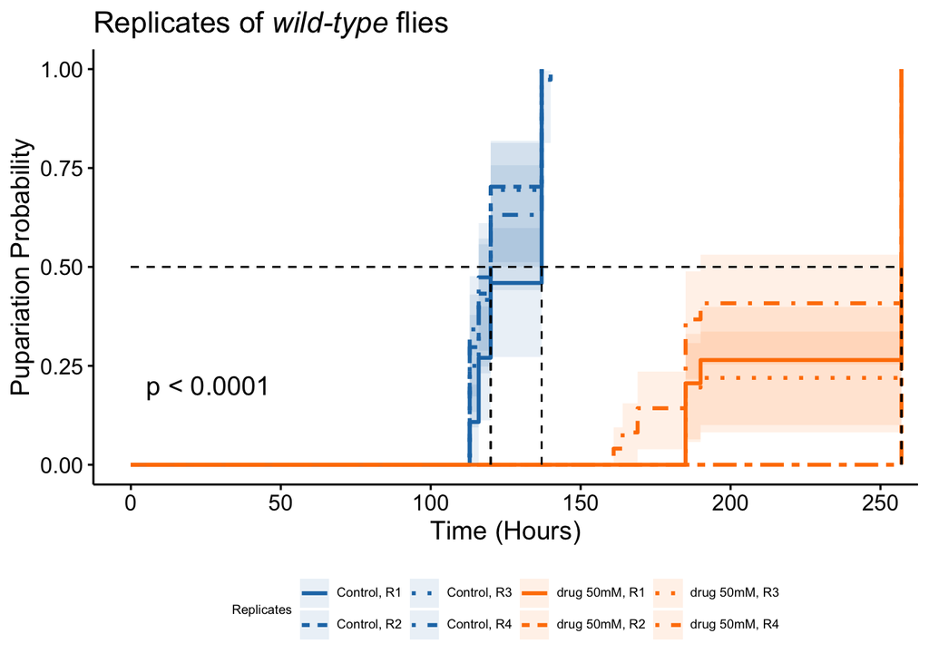

```r
colrs <- brewer.pal(12,"Paired")[c(2,8)]
palette <- c(rep(colrs[1],4), rep(colrs[2],4))
lty_all <- c("solid", "twodash", "dotted", "longdash", "dashed", "dotdash")
line_type <- rep(lty_all[c(1,2,3,6)], 3)
title <- 'Replicates of *wild-type* flies'
legend_labs <- c("Control, R1", "Control, R2", "Control, R3", "Control, R4",
                 "drug 50mM, R1", "drug 50mM, R2", "drug 50mM, R3", "drug 50mM, R4")
model <- survfit(Surv(hour, event) ~ dose + replicate,
                 data=subset(data, genotype=='*wild-type*'))

g <- ggsurvplot(model, data=subset(data, genotype=='*wild-type*'),
                pval = TRUE,                             # adds pval
                fun = "event",                           # invert
                conf.int = TRUE,                         # adds 95% confidence interval
                conf.int.alpha = 0.1,                    # makes it more transparent
                surv.median.line = "hv",                 # adds median points
                palette = palette,
                linetype = line_type,
                title = title,
                xlab = "Time (Hours)",                   # remove x axis label
                ylab = "Pupariation Probability",        # y axis label
                legend.title = "Replicates",             # legend title
                font.legend = c(7),                      # legend size
                legend = "bottom")                       # legend position

l <- levels(g$data.survtable$strata)

g$plot +
  scale_linetype_manual(breaks=l, values=line_type, labels=legend_labs, guide=guide_legend(nrow = 2)) +
  scale_colour_manual(breaks=l, values=palette, labels=legend_labs, guide=guide_legend(nrow = 2)) +
  scale_fill_manual(breaks=l, values=palette, labels=legend_labs, guide=guide_legend(nrow = 2)) +
  theme(legend.text=element_markdown(),
        plot.title = element_markdown())
```

It does look like drug-50mM replicate 2 should be eliminated from the analysis.

Now with *mut<sup>1</sup>* flies:

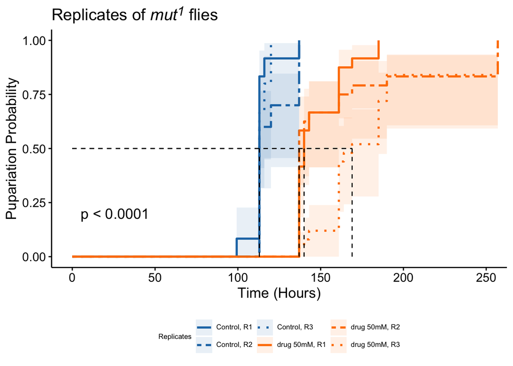

```r
colrs <- brewer.pal(12,"Paired")[c(2,8)]
palette <- c(rep(colrs[1],3), rep(colrs[2],3))
lty_all <- c("solid", "twodash", "dotted", "longdash", "dashed", "dotdash")
line_type <- rep(lty_all[c(1,2,3)], 2)
title <- 'Replicates of *mut^1^* flies'
legend_labs <- c("Control, R1", "Control, R2", "Control, R3",
                 "drug 50mM, R1", "drug 50mM, R2", "drug 50mM, R3")
model <- survfit(Surv(hour, event) ~ dose + replicate,
                 data=subset(data, genotype=='*mut^1^*'))

g <- ggsurvplot(model, data=subset(data, genotype=='*mut^1^*'),
                pval = TRUE,                             # adds pval
                fun = "event",                           # invert
                conf.int = TRUE,                         # adds 95% confidence interval
                conf.int.alpha = 0.1,                    # makes it more transparent
                surv.median.line = "hv",                 # adds median points
                palette = palette,
                linetype = line_type,
                title = title,
                xlab = "Time (Hours)",                   # remove x axis label
                ylab = "Pupariation Probability",        # y axis label
                legend.title = "Replicates",             # legend title
                font.legend = c(7),                      # legend size
                legend = "bottom")                       # legend position

l <- levels(g$data.survtable$strata)

g$plot +
  scale_linetype_manual(breaks=l, values=line_type, labels=legend_labs, guide=guide_legend(nrow = 2)) +
  scale_colour_manual(breaks=l, values=palette, labels=legend_labs, guide=guide_legend(nrow = 2)) +
  scale_fill_manual(breaks=l, values=palette, labels=legend_labs, guide=guide_legend(nrow = 2)) +
  theme(legend.text=element_markdown(),
        plot.title = element_markdown())
```

This is ok. So we can go ahead with everything but replicate 2 of wild-type, drug-50mM.

#### 3.2.2-Full model

[figure not shown]

```r
palette <- brewer.pal(12,"Paired")[c(1,2,7,8)]
lty_all <- c("solid", "twodash", "dotted", "longdash", "dashed", "dotdash")
line_type <- lty_all[c(1,4,1,4)]
title <- 'Effect of *mut^1^* on response to 50mM drug'
legend_labs <- c("*wild-type*, control", "*wild-type*, 50mM drug",
                 "*mut^1^*, control", "*mut^1^*, 50mM drug")
model <- survfit(Surv(hour, event) ~ genotype + dose,
                 data=subset(data, !(genotype=='*wild-type*' & dose==50 & replicate==2)))

g <- ggsurvplot(model,
                data=subset(data, !(genotype=='*wild-type*' & dose==50 & replicate==2)),
                pval = TRUE,                             # adds pval
                fun = "event",                           # invert
                conf.int = TRUE,                         # adds 95% confidence interval
                conf.int.alpha = 0.1,                    # makes it more transparent
                surv.median.line = "hv",                 # adds median points
                palette = palette,
                linetype = line_type,
                title = title,
                xlab = "Time (Hours)",                   # remove x axis label
                ylab = "Pupariation Probability",        # y axis label
                legend.title = "Treatment",             # legend title
                font.legend = c(10),                      # legend size
                legend = "bottom")                       # legend position

l <- levels(g$data.survtable$strata)

g$plot +
  scale_linetype_manual(breaks=l, values=line_type, labels=legend_labs, guide=guide_legend(nrow = 2)) +
  scale_colour_manual(breaks=l, values=palette, labels=legend_labs, guide=guide_legend(nrow = 2)) +
  scale_fill_manual(breaks=l, values=palette, labels=legend_labs, guide=guide_legend(nrow = 2)) +
  theme(legend.text=element_markdown(),
        plot.title = element_markdown())
```

```r
## get median values with confidence interval
surv_median(model)
```

```
##                          strata median lower upper
## 1    genotype=*mut^1^*, dose=0     113   113   113
## 2    genotype=*mut^1^*, dose=50    161   140   161
## 3 genotype=*wild-type*, dose=0     120   120   120
## 4 genotype=*wild-type*, dose=50    257    NA    NA
```

```r
ratedata <- load_devtime_data(filepath, censor=TRUE)
```

```
## establishing time intervals...
## establishing individual events (non-cumulative)...
## establishing event numbers...
## establishing explicit censorings...
## establishing implicit censorings...
```

```r
tail(ratedata)
```

```
## # A tibble: 6 × 7
##   hour      event treatment genotype     dose replicate maxhour
##   <drtn>    <dbl> <chr>     <chr>       <dbl>     <dbl> <drtn>
## 1 257 hours     0 drug      *wild-type*    50         3 257 hours
## 2 257 hours     0 drug      *wild-type*    50         3 257 hours
## 3 257 hours     0 drug      *wild-type*    50         3 257 hours
## 4 257 hours     0 drug      *wild-type*    50         3 257 hours
## 5 257 hours     0 drug      *wild-type*    50         3 257 hours
## 6 257 hours     0 drug      *wild-type*    50         4 257 hours
```

```r
pupas <- ratedata %>%
  subset(!(replicate==2 & genotype=='*wild-type*' & dose==50)) %>%
  filter(event==1) %>%
  group_by(genotype, dose, replicate) %>%
  summarise(n())
rep_size <- 50
pupas$percent <- pupas$`n()`*100/rep_size
pupas <- pupas[c('genotype', 'dose', 'percent')]
pupas
```

```
## # A tibble: 13 × 3
## # Groups:   genotype, dose [4]
##    genotype     dose percent
##    <chr>       <dbl>   <dbl>
##  1 *mut^1^*        0      24
##  2 *mut^1^*        0      40
##  3 *mut^1^*        0      30
##  4 *mut^1^*       50      48
##  5 *mut^1^*       50      48
##  6 *mut^1^*       50      50
##  7 *wild-type*     0      74
##  8 *wild-type*     0      74
##  9 *wild-type*     0      72
## 10 *wild-type*     0      76
## 11 *wild-type*    50      68
## 12 *wild-type*    50      82
## 13 *wild-type*    50      98
```

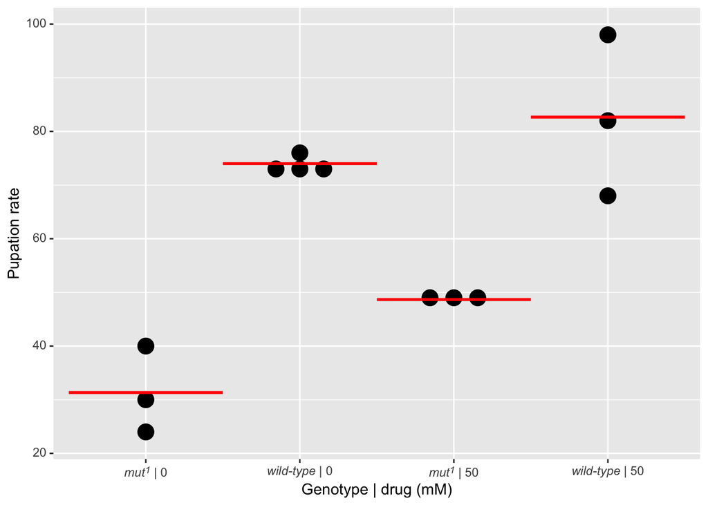

```r
meanlines <- summarise(pupas, mean=mean(percent),
                       by=interaction('genotype', 'dose'), .groups='keep')
meanlines$x <- interaction(meanlines$genotype, meanlines$dose, sep=" | ")

g <- ggplot(pupas, aes(x = interaction(genotype, dose, sep=" | "), y = percent)) +
  geom_dotplot(binaxis='y', stackdir='center', stackratio=1.5, dotsize=1.2) +
  geom_segment(data=meanlines,
               aes(x=as.numeric(x)-0.5, xend=as.numeric(x)+0.5,
                   y=mean, yend=mean),
               colour='red',
               size=1) +
  labs(x = "Genotype | drug (mM)", y="Pupation rate") +
  theme(axis.text.x=element_markdown(),
        axis.text.y=element_markdown())
g
```